# Hands-on session 5: Trajectory Analysis with Monocle3

Basic Implementation of Monocle3 pipeline

Priyansh Srivastava

2023-09-24

# Contents

## 0.1 Introduction

- Monocle introduced the strategy of using RNA-Seq for single-cell trajectory analysis. Rather than purifying cells into discrete states experimentally, Monocle uses an algorithm to learn the sequence of gene expression changes each cell must go through as part of a dynamic biological process. Once it has learned the overall “trajectory” of gene expression changes, Monocle can place each cell at its proper position in the trajectory.
- If there are multiple outcomes for the process, Monocle will reconstruct a “branched” trajectory. These branches correspond to cellular “decisions”, and Monocle provides powerful tools for identifying the genes affected by them and involved in making them.

## 0.2 Pre-requistes

### 0.2.2 Flow of the analysis

### 0.2.3 Required Libraries and Path set ups

To save verbose from various libries we will use the `suppressPackageStartupMessages()`, this suppress the all the package start calls.

```r
suppressPackageStartupMessages(library(SeuratDisk))
suppressPackageStartupMessages(library(Seurat))
suppressPackageStartupMessages(library(monocle3))
suppressPackageStartupMessages(library(tidyverse))
suppressPackageStartupMessages(library(ggplot2)) # For Plotting
suppressPackageStartupMessages(library(wesanderson)) # For Coloring
suppressPackageStartupMessages(library(DT)) # Dynamic tables
```

We will also set paths for input and out data for easir I/O. We are using absolute paths to avoid any conflicts .Throughout the analysis we will save all the data in the native `.RDS` format which is a native format for R.

```r
# Parent directories
inPath = "/home/esr/HandsOn5_A_Monocle3_Trajectory_Analysis/input_data"
outPath = "/home/esr/HandsOn5_A_Monocle3_Trajectory_Analysis/output_data"

# We will also make a few other empty directoires in the outpout folder
imgPath = paste(inPath, "images", sep = "/")
tabPath = paste(inPath, "tables", sep = "/")
rdsPath = paste(inPath, "rObjects", sep = "/")
```

### 0.2.4 Loading the dataset

The Seurat dataset from the previous handsOn-session (*Hands-4: Cell-Type Analysis*). We are using this as the cell-types are already known and it will be easier for us to infer and validate the trajectory of the dataset.

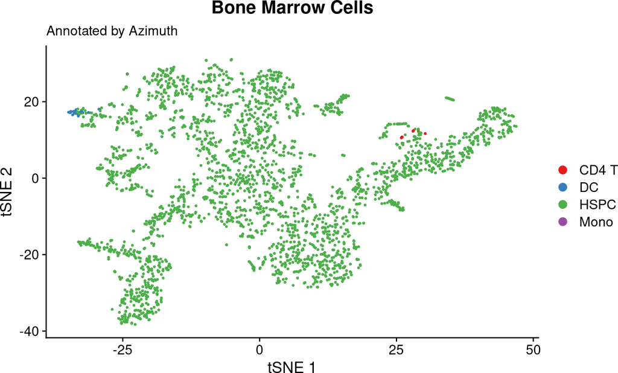

```r
# Load seurat H5 using seurat function
sob = LoadH5Seurat(file = paste(inPath, "setty_seurat_azimuth-classif.h5seurat", sep = "/"),
             verbose = F) # this will suppress all the verbose

# Checcking Data
DimPlot(sob, group.by = "predicted.celltype.l1",reduction = "tsne", ) +
  ggtitle(label = "Bone Marrow Cells", subtitle = "Annotated by Azimuth") +
  xlab("tSNE 1") + ylab("tSNE 2") + scale_color_brewer(palette = "Set1")
```

## 0.3 Analysis

### 0.3.1 Subsetting the seurat object by cell types

In the plot above we see we have a lots of cells when we color the tSNE with higher level labels, and some of the cells does not even exist in the bone marrow. For example it will make much more sense to run trajectory inference on the HSPCs, but we we will include the $CD4^{+}T$ cells it may confound the analysis. We will check it later how it may confound the analysis. Let’s first subset the data.

```r
# Subset the dataset
sob.sub = subset(sob, subset = predicted.celltype.l1 == "HSPC")

# Print consoel
sob.sub
```

```
## An object of class Seurat
## 50505 features across 2942 samples within 4 assays
## Active assay: refAssay (25228 features, 2749 variable features)
##  3 other assays present: RNA, prediction.score.celltype.l1, prediction.score.celltype.l2
##  4 dimensional reductions calculated: pca, ref.umap, tsne, integrated_dr
```

### 0.3.2 Creation of `cell_data_set` object for Monocle3

- `CDS` aka `cell_data_set`, is the S4 which is used by the Monocle3. It inherits all the slots of the `SingleCellExperiment` Class. Additinally it stores information about the principal graph and, trajectory etc.
- Just like the `SingleCellExperiment`, the `cell_data_set` also requires the following,
  1. **Count Table**: We can extract it from the seurat object. Ideally this has to be supplied in the `dgCMatrix` class.
  2. **Cell Metadata**: This is a R dataframe, where the rownames correspond to the columns of the counts and the columns contain information about the cells. Such as exprimental capture time or cell type annotation labels in our case.
  3. **Gene Metadata**: This is also a R dataframe, where the rownames correspond to the rows of the counts and the columns contain information about the genes Such as gene functions, symbols or ontologies etc. Also, this dataframe should have a column by the name of **“gene_short_name”**, which is later used in plotting fucntion of the Monocle3.

Let’s do it one by one and inspect the data. We start with the *rawCounst*, don’t worry we will later also show you how to do the analysis with normalized data.

```r
# Extract the Raw counts
rawCounts <- sob.sub@assays$RNA@counts

# View a few line of data
datatable(as.data.frame(rawCounts[c(1:20),c(1:20)]))
```

|  | GACAGAGCAGGAATGC | GCGGGTTGTCGTTGTA | AGTGAGGCAGCCTGTG | AGACGTTGTAGGCATG | GAGTCCGTCAGTGTTG | GCAGTTATCCTGTACC | AGGCCACTCACATAGC | GATGCTAGTCATCCCT | TACCTTATCTGAGGGA | CTAATGGTCCTTGCCA | TTAGGACCACTGCCAG | TAAGAGAGTGAAGGCT | CCTTCGACACATCCGG | CCATTCGCATGGGAAC | GTAACGTAGTTGCAGG | ACACCCTAGGTGCAAC | ACACCGGAGAGAACAG | CAACCTCGTCTGCCAG | TGGCTGGAGCTACCGC | ATCGAGTAGTACACCT |
| --- | --- | --- | --- | --- | --- | --- | --- | --- | --- | --- | --- | --- | --- | --- | --- | --- | --- | --- | --- | --- |
| ENSG00000268903 | 0 | 0 | 0 | 0 | 0 | 0 | 0 | 0 | 0 | 0 | 0 | 0 | 0 | 0 | 0 | 0 | 0 | 0 | 0 | 0 |
| ENSG00000228463 | 0 | 0 | 0 | 0 | 0 | 0 | 0 | 0 | 0 | 0 | 0 | 0 | 0 | 0 | 0 | 0 | 0 | 0 | 0 | 0 |
| ENSG00000230021 | 0 | 0 | 0 | 0 | 0 | 0 | 1 | 0 | 0 | 0 | 1 | 1 | 0 | 0 | 2 | 0 | 0 | 1 | 0 | 0 |
| MTND1P23 | 8 | 2 | 7 | 0 | 4 | 1 | 3 | 7 | 2 | 0 | 3 | 7 | 13 | 11 | 3 | 2 | 14 | 11 | 3 | 0 |
| MTND2P28 | 0 | 0 | 2 | 0 | 0 | 0 | 0 | 0 | 0 | 0 | 0 | 0 | 0 | 0 | 0 | 0 | 0 | 0 | 0 | 0 |
| MTCO1P12 | 3 | 4 | 4 | 2 | 11 | 4 | 7 | 10 | 3 | 3 | 3 | 7 | 11 | 6 | 2 | 2 | 6 | 5 | 5 | 3 |
| MTCO2P12 | 0 | 0 | 0 | 0 | 0 | 0 | 0 | 0 | 0 | 0 | 0 | 0 | 0 | 0 | 0 | 0 | 0 | 0 | 0 | 0 |
| MTATP6P1 | 0 | 1 | 0 | 0 | 1 | 0 | 0 | 2 | 0 | 1 | 2 | 2 | 0 | 3 | 0 | 0 | 3 | 3 | 1 | 0 |
| MTCO3P12 | 0 | 0 | 0 | 0 | 1 | 0 | 0 | 0 | 0 | 0 | 0 | 0 | 0 | 0 | 0 | 0 | 0 | 0 | 0 | 0 |
| LINC01409 | 0 | 0 | 0 | 0 | 0 | 0 | 0 | 0 | 0 | 0 | 0 | 0 | 0 | 0 | 1 | 0 | 0 | 0 | 0 | 0 |

[output cut: 10 more lines]

Now we extract the cell level metadata. We will also plot how much of each cell type we have. We make the plots using the finer resolution hiereachy of teh cell types.

```r
# Extract the Raw counts
cellMetaData <- sob.sub@meta.data

# View a few line of data
datatable(cellMetaData)
```

|  | nCount_RNA | nFeature_RNA | orig.ident | percent.mt | S.Score | G2M.Score | Phase | RNA_snn_res.0.5 | seurat_clusters | nCount_refAssay | nFeature_refAssay | predicted.celltype.l2.score | predicted.celltype.l2 | predicted.celltype.l1.score | predicted.celltype.l1 | mapping.score |
| --- | --- | --- | --- | --- | --- | --- | --- | --- | --- | --- | --- | --- | --- | --- | --- | --- |
| GACAGAGCAGGAATGC | 4157 | 1852 | healthyBM | 4.233822468126053 | -0.08714211355420678 | -0.08991974442618253 | G1 | 6 | 6 | 4157 | 1852 | 0.6301262078974074 | GMP | 1 | HSPC | 0.9452756247791662 |
| GCGGGTTGTCGTTGTA | 3661 | 1990 | healthyBM | 2.676864244741874 | 0.7746201411570515 | 0.7417648862453905 | S | 3 | 3 | 3661 | 1990 | 0.9876846711587762 | pre B | 0.9999999999999999 | HSPC | 0.936588933446641 |
| AGTGAGGCAGCCTGTG | 4417 | 2178 | healthyBM | 3.599728322390763 | -0.1962170797121547 | -0.21445120928005 | G1 | 0 | 0 | 4417 | 2178 | 0.4751612482884038 | CLP | 1 | HSPC | 0.7003396742352274 |
| AGACGTTGTAGGCATG | 4415 | 2085 | healthyBM | 3.080407701019253 | -0.2091189272803347 | -0.2448909805995247 | G1 | 0 | 0 | 4415 | 2085 | 0.5642511004962428 | LMPP | 0.9902269652350374 | HSPC | 0.9338438440013005 |
| GAGTCCGTCAGTGTTG | 6881 | 2832 | healthyBM | 3.008283679697719 | -0.1307276821329345 | -0.1289203901130713 | G1 | 7 | 7 | 6881 | 2832 | 0.9889966212286987 | Early Eryth | 0.9889966212286987 | HSPC | 0.9677857700218976 |
| GCAGTTATCCTGTACC | 3643 | 2107 | healthyBM | 2.799890200384299 | -0.1863134637032378 | -0.1857360558116914 | G1 | 2 | 2 | 3643 | 2107 | 0.438498498218168 | EMP | 1 | HSPC | 0.951021192262319 |
| AGGCCACTCACATAGC | 6479 | 2553 | healthyBM | 2.90168235838864 | -0.1478478902146065 | -0.1469283337309401 | G1 | 6 | 6 | 6479 | 2553 | 0.3777264226166684 | LMPP | 0.9999999999999999 | HSPC | 0.8943318664703759 |
| GATGCTAGTCATCCCT | 6956 | 2934 | healthyBM | 4.039677975848189 | -0.1216568247196251 | -0.1475497574396464 | G1 | 2 | 2 | 6956 | 2934 | 0.9599881542137008 | Early Eryth | 0.964402997752773 | HSPC | 0.9642563799281245 |
| TACCTTATCTGAGGGA | 5501 | 2245 | healthyBM | 3.090347209598255 | 0.03929406609380459 | 0.0224728409463123 | S | 5 | 5 | 5501 | 2245 | 0.9988991485580643 | GMP | 0.9999999999999994 | HSPC | 0.9891379745152898 |
| CTAATGGTCCTTGCCA | 3914 | 2126 | healthyBM | 2.146142054164538 | 0.02295437527601585 | 0.04388885028919071 | G2M | 0 | 0 | 3914 | 2126 | 0.6785206163001518 | CLP | 0.9278038846871742 | HSPC | 0.9795204062624495 |

[output cut: 2932 more lines]

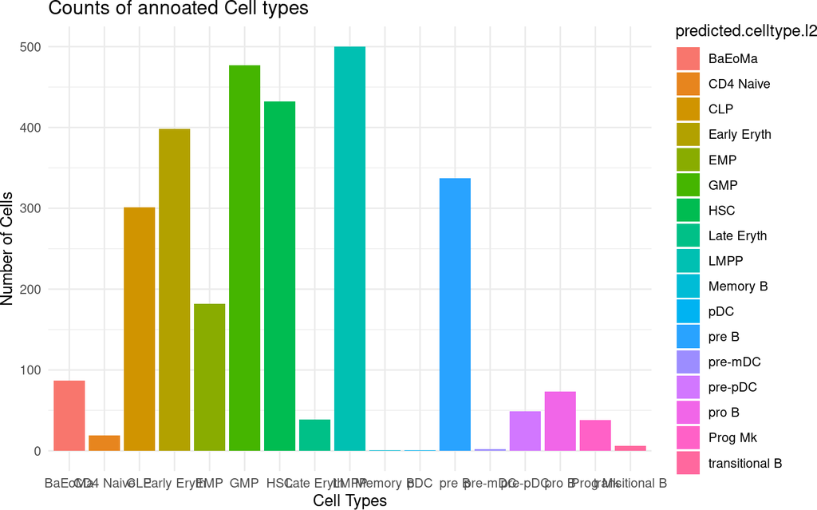

```r
# Plot  of cell types
cellMetaData %>%
  group_by(predicted.celltype.l2) %>%
  summarise(count = n()) %>%
  ggplot(aes(x=predicted.celltype.l2, y=count, fill=predicted.celltype.l2)) +
  geom_bar(stat="identity") + #scale_fill_brewer(palette = "Set3")+
  labs(x="Cell Types", y="Number of Cells", title="Counts of annoated Cell types") +
  theme(axis.text.x = element_text(angle = 45, hjust = 1, vjust = 0.5)) +
  theme_minimal()
```